# CS 556 Final Group Project: Near-Earth Objects

### *Jay Talekar, Jaydeep Maganbhai Dobariya, Syed Z. Raza*

```python
import pandas as pd
import numpy as np
import matplotlib.pyplot as plt
%matplotlib inline
import seaborn as sns
```

## Exploratory Data Analysis

### Example Rows from the Dataset

```python
df = pd.read_csv("./NASA.csv")
df.head()
```

|  | id | name | est_diameter_min | est_diameter_max | relative_velocity | miss_distance | orbiting_body | sentry_object | absolute_magnitude | hazardous |
| --- | --- | --- | --- | --- | --- | --- | --- | --- | --- | --- |
| 0 | 2162635 | 162635 (2000 SS164) | 1.198271 | 2.679415 | 13569.249224 | 5.483974e+07 | Earth | False | 16.73 | False |
| 1 | 2277475 | 277475 (2005 WK4) | 0.265800 | 0.594347 | 73588.726663 | 6.143813e+07 | Earth | False | 20.00 | True |
| 2 | 2512244 | 512244 (2015 YE18) | 0.722030 | 1.614507 | 114258.692129 | 4.979872e+07 | Earth | False | 17.83 | False |
| 3 | 3596030 | (2012 BV13) | 0.096506 | 0.215794 | 24764.303138 | 2.543497e+07 | Earth | False | 22.20 | False |
| 4 | 3667127 | (2014 GE35) | 0.255009 | 0.570217 | 42737.733765 | 4.627557e+07 | Earth | False | 20.09 | True |

### Missing Data?

Are there any missing values in our dataset? To answer this question, let's use Seaborn. In thee following visualization, we use a heatmap to highlight where the NaN values are in each column, if any:

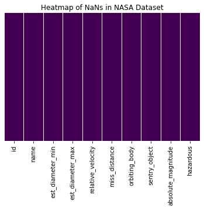

```python
sns.heatmap(df.isnull(), yticklabels=False, cbar=False, cmap='viridis')
plt.title("Heatmap of NaNs in NASA Dataset")
plt.show()
```

```python
np.sum(df.isnull())
```

```
id                    0
name                  0
est_diameter_min      0
est_diameter_max      0
relative_velocity     0
miss_distance         0
orbiting_body         0
sentry_object         0
absolute_magnitude    0
hazardous             0
dtype: int64
```

**Takeaway:** woohoo! we have no NaNs.

### Redundant Features?

One of our priorities in creating machine learning models is to inherit a *low-variance, low-bias model*. Put differently, we want our model to be able to understand the full range of values that can influence the final label, without paying attention to features that don't really add useful information for making our classification.

OK having said this - do we have any columns in our dataset that only contain 1 unique value?

```python
sentry_dist = df['sentry_object'].value_counts()
sentry_dist.values
```

```
array([90836])
```

(I have a hunch there is only 1 value in this column - let's visualize):

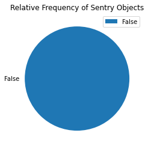

```python
plt.pie(sentry_dist.values, labels=sentry_dist.keys())
plt.title('Relative Frequency of Sentry Objects')
plt.legend()
plt.show()
```

Let's also do this for the other categorical predictor variable - i.e., the `orbiting_body`. For the fun, I'll do so using another kind of visualization:

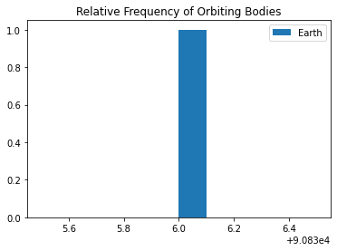

```python
orbit_dist = df['orbiting_body'].value_counts()

plt.hist(orbit_dist.values, label=orbit_dist.keys())
plt.title('Relative Frequency of Orbiting Bodies')
plt.legend()
plt.show()
```

**Takeaway:** well then! It looks like both the `orbiting_body` and `sentry_object` columns are constant! So we can go ahead and drop them from the dataset, once we start modeling.

On a related note - the `id` column probably will not offer any relevant information for making classifications either. So we'll drop that as well:

```python
df_dropped = df.drop(labels=['id', 'orbiting_body', 'sentry_object'], axis=1)
df_dropped.head()
```

|  | name | est_diameter_min | est_diameter_max | relative_velocity | miss_distance | absolute_magnitude | hazardous |
| --- | --- | --- | --- | --- | --- | --- | --- |
| 0 | 162635 (2000 SS164) | 1.198271 | 2.679415 | 13569.249224 | 5.483974e+07 | 16.73 | False |
| 1 | 277475 (2005 WK4) | 0.265800 | 0.594347 | 73588.726663 | 6.143813e+07 | 20.00 | True |
| 2 | 512244 (2015 YE18) | 0.722030 | 1.614507 | 114258.692129 | 4.979872e+07 | 17.83 | False |
| 3 | (2012 BV13) | 0.096506 | 0.215794 | 24764.303138 | 2.543497e+07 | 22.20 | False |
| 4 | (2014 GE35) | 0.255009 | 0.570217 | 42737.733765 | 4.627557e+07 | 20.09 | True |

### Hazardous NEOs Over Time?

We observe that in the `name` column, the years of each near Earth object (NEO) is provided. Wouldn't it be interesting to see if the number of hazardous NEOs over time is trending up or down?

To do this - let's begin by engineering a new column that contains just the year of each record in the dataset:

```python
def extract_year(name: str) -> int:
    start_index = name.find("(") + 1
    year_chars = list(name)[start_index:start_index + 4]
    return int(''.join(year_chars))


def locate_names_with_no_year(names: str) -> str:
    years, nonyears = [], []
    for index, name in enumerate(names):
        try:
            years.append(extract_year(name))
        except ValueError:
            nonyears.append((index, name))
    return years, nonyears
```

```python
years, year_not_found = locate_names_with_no_year(df_dropped["name"])
year_not_found
```

```
[(1847, '719 Albert (A911 TB)'),
 (12709, '433 Eros (A898 PA)'),
 (36418, '1036 Ganymed (A924 UB)'),
 (37651, '433 Eros (A898 PA)'),
 (56533, '433 Eros (A898 PA)'),
 (73482, '(A/2019 Q2)')]
```

```python
aggregate_hazard_yrs = years_and_hazards.groupby("Year", sort=True).sum()
```

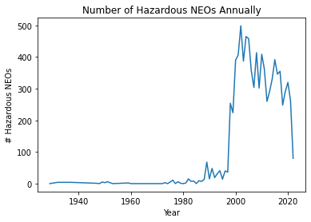

```python
plt.plot(aggregate_hazard_yrs.index,
         aggregate_hazard_yrs.values)
plt.title("Number of Hazardous NEOs Annually")
plt.ylabel('# Hazardous NEOs')
plt.xlabel('Year')
plt.show()
```

**Takeaway:** interesting! Without knowing too much about the domain, our team is not sure what to make of this trend. The observation is that the number of hazardous NEOs seems to spike around the turn of the century. However, it does not explain why. To be on the conservative side, we presume that this spike is merely due to extraneous factors (e.g. perhaps in improved detection technology by NASA). It does not seem likely that the probability of a NEO being hazardous should suddenly spike because of the year it occurs.

Going forward, we will focus on trying to build a classifier that predicts just based on the actual physical properties of a given NEO, and leave the year out of the dataset.

```python
df_dropped2 = df_dropped.drop(labels=["name"], axis=1)
df_dropped2.head()
```

|  | est_diameter_min | est_diameter_max | relative_velocity | miss_distance | absolute_magnitude | hazardous |
| --- | --- | --- | --- | --- | --- | --- |
| 0 | 1.198271 | 2.679415 | 13569.249224 | 5.483974e+07 | 16.73 | False |
| 1 | 0.265800 | 0.594347 | 73588.726663 | 6.143813e+07 | 20.00 | True |
| 2 | 0.722030 | 1.614507 | 114258.692129 | 4.979872e+07 | 17.83 | False |
| 3 | 0.096506 | 0.215794 | 24764.303138 | 2.543497e+07 | 22.20 | False |
| 4 | 0.255009 | 0.570217 | 42737.733765 | 4.627557e+07 | 20.09 | True |

```python
df_dropped2.describe()
```

|  | est_diameter_min | est_diameter_max | relative_velocity | miss_distance | absolute_magnitude |
| --- | --- | --- | --- | --- | --- |
| count | 90836.000000 | 90836.000000 | 90836.000000 | 9.083600e+04 | 90836.000000 |
| mean | 0.127432 | 0.284947 | 48066.918918 | 3.706655e+07 | 23.527103 |
| std | 0.298511 | 0.667491 | 25293.296961 | 2.235204e+07 | 2.894086 |
| min | 0.000609 | 0.001362 | 203.346433 | 6.745533e+03 | 9.230000 |
| 25% | 0.019256 | 0.043057 | 28619.020645 | 1.721082e+07 | 21.340000 |
| 50% | 0.048368 | 0.108153 | 44190.117890 | 3.784658e+07 | 23.700000 |
| 75% | 0.143402 | 0.320656 | 62923.604633 | 5.654900e+07 | 25.700000 |
| max | 37.892650 | 84.730541 | 236990.128088 | 7.479865e+07 | 33.200000 |

## Feature & Model Selection

The goals of this section are:

1. to determine which features we want to actually use for the model,
2. and on the flip side, which classifier type we want to use for the chosen features - a logistic regression, or support vector machine (potentially making use of the kernel trick?)

### Checking Correlations

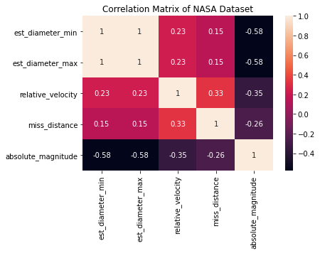

```python
sns.heatmap(X_train.corr(), annot=True)
plt.title("Correlation Matrix of NASA Dataset")
plt.show()
```

**Takeaway:** apart from `est_diameter_min` and `est_diameter_max`, there does not seem to be any strong multicolinearity between features in this dataset.

So it would be prudent to drop either the `est_diameter_min` or `est_diameter_max` column, to help prevent overfitting.

This is just a hunch, but let's decide to drop the `est_diameter_max` before going forward - we presumably want our model to be very sensitive to the size of an NEO (after all, we don't want to miss any incoming hazards!); in this way, our model will learn to pick up on even small potential hazards.

Before going into next steps, let's standardize our predictor variables as well:

```python
X_train = X_train.drop("est_diameter_max", axis=1)
X_test = X_test.drop("est_diameter_max", axis=1)
```

```python
scaler = StandardScaler()
X_train_scaled = scaler.fit_transform(X_train)
X_test_scaled = scaler.transform(X_test)
```

## Modeling (4 Features)

### 1: SVM (Lagrange Multipliers)

#### Searching for the Best Kernel and Class Weight

Because we know this dataset is non-balanced, we will grid search for the right class weight. And we also don't know if we have linear separability or not, so for this first model let's try to also search for the best kernel to use:

```python
from sklearn.linear_model import SGDClassifier
from sklearn.model_selection import GridSearchCV
from sklearn.svm import SVC
```

```python
param_grid1 = {
    "kernel": ['linear', 'poly', 'rbf', 'sigmoid'],
    "class_weight": [None, "balanced"]  # this is less important to search for right now
}
```

```python
# grid1 = GridSearchCV(SVC(),
#                      param_grid1,
#                      refit=True,
#                      cv=2,  # skipping cross validation for now
#                      verbose=2)
# grid1.fit(X_train_scaled, np.squeeze(y_train))
```

^Takes too long to fit, so Colab crashes before it can complete. Instead, we'll try a more efficient way of doing this via gradient descent:

### 2: Linear SVM (Gradient Descent)

```python
param_grid2 = {
    "class_weight": [None, "balanced"],
    "penalty": ["l2"],  # let's avoid l1, b/c we've already selected features
    "random_state": [42],  # for reproducibility purposes
    "average": [True, False],
    "max_iter": [5000],
    "alpha": [.0001, .01, 10], # regularization param
    "learning_rate": ["optimal", "adaptive"],
    "eta0": [0.001],  # we can tune this further, but for now I
                      # just want to see if using an
                      # adaptive schedule vs. an optimal one has any value
                      # in the first place
    # these next two will help us not waste compute time
    "early_stopping":  [True],
    "validation_fraction": [0.1]
}
```

Note: this is just using a linear kernel for now

```python
grid2 = GridSearchCV(SGDClassifier(loss="hinge"),
                     param_grid2,
                     refit=True,
                     cv=5,  # skipping cross validation for now
                     verbose=2)
grid2.fit(X_train_scaled, np.squeeze(y_train))
```

[output not shown]

[output cut: 95 more lines]

```
GridSearchCV(cv=5, estimator=SGDClassifier(),
             param_grid={'alpha': [0.0001, 0.01, 10], 'average': [True, False],
                         'class_weight': [None, 'balanced'],
                         'early_stopping': [True], 'eta0': [0.001],
                         'learning_rate': ['optimal', 'adaptive'],
                         'max_iter': [5000], 'penalty': ['l2'],
                         'random_state': [42], 'validation_fraction': [0.1]},
             verbose=2)
```

OK nice! We've tried a best of combinations - let's see what the best parameters turned out to be:

```python
grid2.best_params_
```

```
{'alpha': 0.0001,
 'average': True,
 'class_weight': None,
 'early_stopping': True,
 'eta0': 0.001,
 'learning_rate': 'optimal',
 'max_iter': 5000,
 'penalty': 'l2',
 'random_state': 42,
 'validation_fraction': 0.1}
```

Now, let's evaluate the best model so far:

```python
from sklearn.metrics import (
    classification_report,
    ConfusionMatrixDisplay
)
```

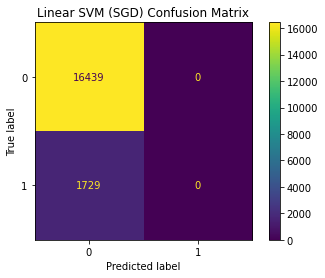

```python
ConfusionMatrixDisplay.from_estimator(grid2.best_estimator_,
                                      X_test_scaled, y_test)
plt.title("Linear SVM (SGD) Confusion Matrix")
plt.show()
```

```python
print(
    classification_report(y_test,
                          grid2.best_estimator_.predict(X_test_scaled))
)
```

```
              precision    recall  f1-score   support

           0       0.90      1.00      0.95     16439
           1       0.00      0.00      0.00      1729

    accuracy                           0.90     18168
   macro avg       0.45      0.50      0.48     18168
weighted avg       0.82      0.90      0.86     18168
```

Good news: the test accuracy is high!

Bad news: the model has totally given up on being predicting the hazardous NEOs.

What can we do to remedy this, so that we improve the number of true positives predicted by our model?

### 3: Linear SVM (Balanced Class Weights, Gradient Descent)

Let's create a model that's nearly the same as before, but just with one small change - this time, we will weigh the positive (aka, the minority class) higher in our optimization:

```python
params_to_use = grid2.best_params_.copy()
params_to_use["class_weight"] = "balanced"
model3 = SGDClassifier(**params_to_use)
model3 = model3.fit(X_train_scaled, np.squeeze(y_train))
```

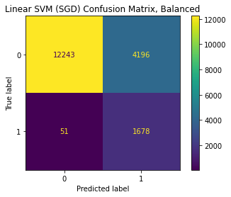

```python
ConfusionMatrixDisplay.from_estimator(model3,
                                      X_test_scaled,
                                      y_test)
plt.title("Linear SVM (SGD) Confusion Matrix, Balanced")
plt.show()
```

```python
print(
    classification_report(y_test,
                          model3.predict(X_test_scaled))
)
```

```
              precision    recall  f1-score   support

           0       1.00      0.74      0.85     16439
           1       0.29      0.97      0.44      1729

    accuracy                           0.77     18168
   macro avg       0.64      0.86      0.65     18168
weighted avg       0.93      0.77      0.81     18168
```

**Takeaways:**

1. *Good news*: the recall for our positive class has indeed improved!
2. *Bad News:* Our test accuracy has taken a hit :(
3. Even though this would be a much safer model to use in the real world, perhaps there is some way we can achieve high accuracy for both classes?

### 4: Kernel SVM (RBF, Balanced Class Weights, Gradient Descent)

The intuition here is that it's possible that our classes are not linearly separable. So, perhaps the key to building a highly accurate AND highly precise model is to use a non-linear kernel. Let's try that now:

```python
from sklearn.kernel_approximation import Nystroem
```

```python
# these args are totally arbitrary, just copying the docs for now:
# https://scikit-learn.org/stable/modules/generated/sklearn.kernel_approximation.Nystroem.html#sklearn.kernel_approximation.Nystroem

feature_map_nystroem1 = Nystroem(gamma=.2,
                                random_state=1,
                                n_components=300)
```

```python
best_params4 = {
    'alpha': 0.0001,
    'average': True,
    'class_weight': "balanced",
    'early_stopping': True,
    'eta0': 0.001,
    'learning_rate': 'optimal',
    'max_iter': 5000,
    'penalty': 'l2',
    'random_state': 42,
    'validation_fraction': 0.1
}
```

```python
X_train_rbf = feature_map_nystroem1.fit_transform(X_train_scaled)
X_test_rbf = feature_map_nystroem1.transform(X_test_scaled)
```

```python
model4 = SGDClassifier(**best_params4)
model4 = model4.fit(X_train_rbf, np.squeeze(y_train))
```

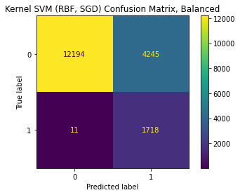

```python
ConfusionMatrixDisplay.from_estimator(model4,
                                      X_test_rbf,
                                      y_test)
plt.title("Kernel SVM (RBF, SGD) Confusion Matrix, Balanced")
plt.show()
```

```python
print(
    classification_report(y_test,
                          model4.predict(X_test_rbf))
)
```

```
              precision    recall  f1-score   support

           0       1.00      0.74      0.85     16439
           1       0.29      0.99      0.45      1729

    accuracy                           0.77     18168
   macro avg       0.64      0.87      0.65     18168
weighted avg       0.93      0.77      0.81     18168
```

**Takeaways**:

1. *Pros*: this model has a better recall on the positive class than our 3rd model
2. *Cons*: our overall accuracy has still not really improved by that much.

Let's try one more time, just to see if tuning the feature map can help:

### 5: One Class SVM

Like before:

- we'll use gradient descent to optimize the model, due to the size of our dataset
- we'll use an RBF kernel, due to the nature of our data probably being nonlinear (as we saw earlier, using the RBF kernel improved our recall)
- the difference is, now we'll train the model only to recognize the non-hazardous examples - in this way, anything that is hazardous can potentially be immediately flagged as being out of the normal (said differently, as an "outlier")

```python
from sklearn.linear_model import SGDOneClassSVM
```

```python
# start by reloading the data, and separating both classes
data = df_dropped2.drop("est_diameter_max", axis=1)
# encode the class column, since I forgot to do before
data["hazardous"] = LabelEncoder().fit_transform(data["hazardous"])
train, test = train_test_split(data, test_size=.2, random_state=42)
```

```python
train.head()  # sanity check
```

|  | est_diameter_min | relative_velocity | miss_distance | absolute_magnitude | hazardous |
| --- | --- | --- | --- | --- | --- |
| 35538 | 0.038420 | 91103.489666 | 6.350550e+07 | 24.2 | 0 |
| 40393 | 0.192555 | 28359.611312 | 2.868167e+07 | 20.7 | 0 |
| 58540 | 0.004619 | 107351.426865 | 5.388098e+04 | 28.8 | 0 |
| 61670 | 0.015295 | 21423.536884 | 5.103884e+07 | 26.2 | 0 |
| 11435 | 0.011603 | 69856.053840 | 7.360836e+07 | 26.8 | 0 |

We'll also have to measure the percentage of positive examples in our dataset again - this will be how we'll "weigh" this one class model:

```python
num_positive = train[train["hazardous"] == 1].shape[0]
outlier_proportion = num_positive / float(train.shape[0])
```

Now, we're almost ready to train the one-class model. But I want to make sure we can use the kernel trick, so let's go ahead and transform this data.

We'll make a few different feature maps this time, so it'll help us in tuning the `gamma` parameter of our RBF:

```python
gammas = [0.00001, 0.001, 0.01, 0.05, 0.1, 1, 5, 10, 100]
gamma_kernel = dict()

for g in gammas:
    feature_map = Nystroem(gamma=g,
                           random_state=1,
                           n_components=300)
    # splitting claases in training data + processing
    train_normal, train_outlier = (
        train[train["hazardous"] == 0],
        train[train["hazardous"] == 1],
    )
    X_train, y_train = (
        train_normal.drop("hazardous", axis=1),
        train_normal["hazardous"],
    )
    X_test, y_test = (  # note: we include both classes in the test data
        test.drop("hazardous", axis=1),
        test["hazardous"],
    )
    scaler = StandardScaler()
    X_train_scaled_normal = scaler.fit_transform(X_train)
    X_test_scaled = scaler.transform(X_test)
    # apply the kernel
    X_train_rbf = feature_map.fit_transform(X_train_scaled_normal)
    X_test_rbf = feature_map.transform(X_test_scaled)
    gamma_kernel[g] = (X_train_rbf, X_test_rbf, y_train, y_test)
```

Let's get training:

```python
models = dict()

for g, X in gamma_kernel.items():
    X_train_rbf, _, _, _ = X
    svm = SGDOneClassSVM(nu=outlier_proportion,
                         **params_to_use5)
    models[g] = svm.fit(X_train_rbf)
```

And, let's get testing!

```python
def evaluate_one_class_svm(model, X_test, y_test, gamma=None):
    y_pred = model.predict(X_test)
    # relabel y_pred so -1 --> our positive class, and 1 --> our negatives
    y_pred_transformed = np.where(y_pred == -1, 1, 0)
    # visualize the confusion matrix
    ConfusionMatrixDisplay.from_predictions(y_test, y_pred_transformed)
    plt.title(f"One-Class SVM (RBF) Confusion Matrix, g = {gamma}")
    plt.show()
    print(classification_report(y_test, y_pred_transformed))
```

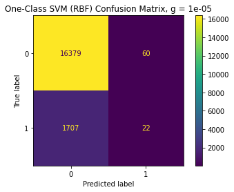

```
              precision    recall  f1-score   support

           0       0.91      1.00      0.95     16439
           1       0.27      0.01      0.02      1729

    accuracy                           0.90     18168
   macro avg       0.59      0.50      0.49     18168
weighted avg       0.84      0.90      0.86     18168
```

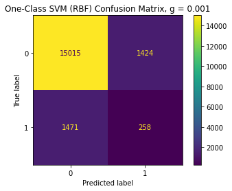

```
              precision    recall  f1-score   support

           0       0.91      0.91      0.91     16439
           1       0.15      0.15      0.15      1729

    accuracy                           0.84     18168
   macro avg       0.53      0.53      0.53     18168
weighted avg       0.84      0.84      0.84     18168
```

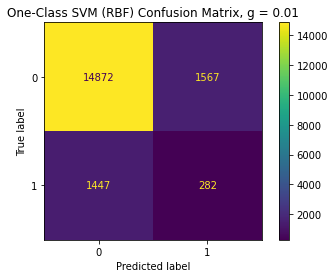

```
              precision    recall  f1-score   support

           0       0.91      0.90      0.91     16439
           1       0.15      0.16      0.16      1729

    accuracy                           0.83     18168
   macro avg       0.53      0.53      0.53     18168
weighted avg       0.84      0.83      0.84     18168
```

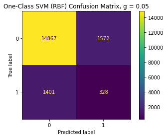

```
              precision    recall  f1-score   support

           0       0.91      0.90      0.91     16439
           1       0.17      0.19      0.18      1729

    accuracy                           0.84     18168
   macro avg       0.54      0.55      0.54     18168
weighted avg       0.84      0.84      0.84     18168
```

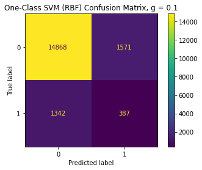

```
              precision    recall  f1-score   support

           0       0.92      0.90      0.91     16439
           1       0.20      0.22      0.21      1729

    accuracy                           0.84     18168
   macro avg       0.56      0.56      0.56     18168
weighted avg       0.85      0.84      0.84     18168
```

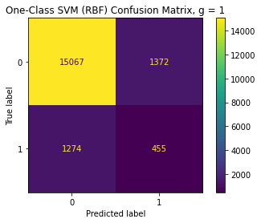

```
              precision    recall  f1-score   support

           0       0.92      0.92      0.92     16439
           1       0.25      0.26      0.26      1729

    accuracy                           0.85     18168
   macro avg       0.59      0.59      0.59     18168
weighted avg       0.86      0.85      0.86     18168
```

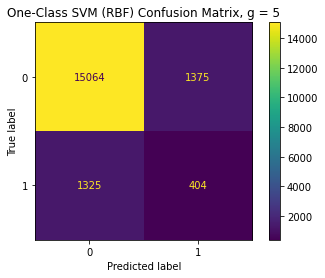

```
              precision    recall  f1-score   support

           0       0.92      0.92      0.92     16439
           1       0.23      0.23      0.23      1729

    accuracy                           0.85     18168
   macro avg       0.57      0.58      0.57     18168
weighted avg       0.85      0.85      0.85     18168
```

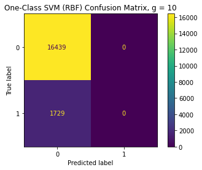

```
              precision    recall  f1-score   support

           0       0.90      1.00      0.95     16439
           1       0.00      0.00      0.00      1729

    accuracy                           0.90     18168
   macro avg       0.45      0.50      0.48     18168
weighted avg       0.82      0.90      0.86     18168
```

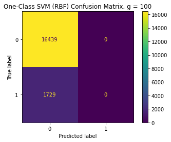

```
              precision    recall  f1-score   support

           0       0.90      1.00      0.95     16439
           1       0.00      0.00      0.00      1729

    accuracy                           0.90     18168
   macro avg       0.45      0.50      0.48     18168
weighted avg       0.82      0.90      0.86     18168
```

```python
results = list()

for g, X in gamma_kernel.items():
    _, X_test_rbf, _, y_test = X
    svm = models[g]
    evaluate_one_class_svm(svm, X_test_rbf, y_test, gamma=g)
```

## Dimensionality Reduction using PCA

### Visualizing, Standardizing and Splitting

#### Visualizing each feature wrt other features using Scatterplot

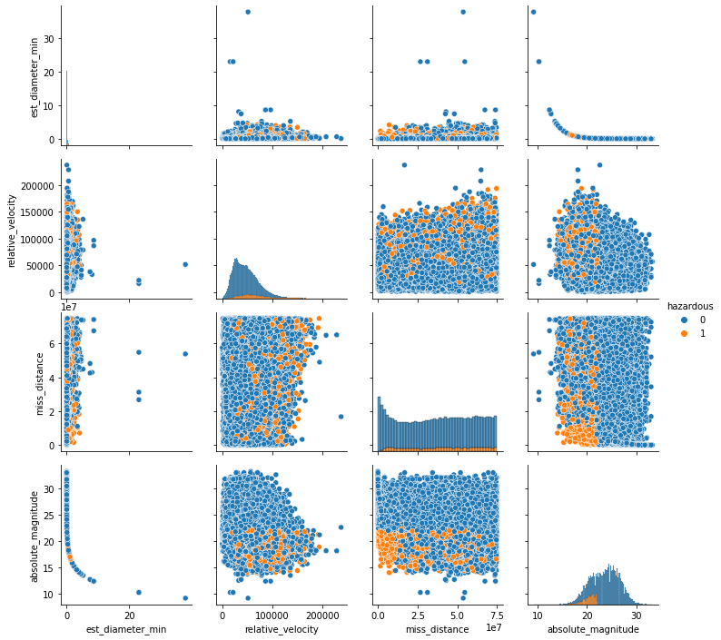

```python
g = sns.PairGrid(data, hue="hazardous")
g.map_offdiag(sns.scatterplot)
g.map_diag(sns.histplot, multiple='stack')
g.add_legend()
```

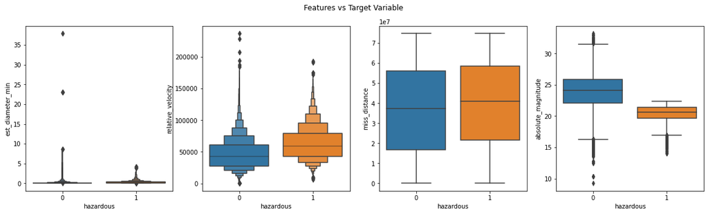

```python
fig, axes = plt.subplots(1, 4, figsize = (20, 5))
fig.suptitle("Features vs Target Variable")
sns.boxenplot(ax=axes[0], x='hazardous',y='est_diameter_min',data=data)
sns.boxenplot(ax=axes[1], x='hazardous',y='relative_velocity',data=data)
sns.boxplot(ax=axes[2], x='hazardous',y='miss_distance',data=data)
sns.boxplot(ax=axes[3], x='hazardous',y='absolute_magnitude',data=data)
plt.show()
```

```python
X_train, X_test, y_train, y_test = train_test_split(X, y,
                                                    test_size=0.2,
                                                    random_state=42)
```

```python
scaler = StandardScaler()
X_train = scaler.fit_transform(X_train)
X_test = scaler.transform(X_test)
```

### Finding 2 Principal Components with PCA

```python
from sklearn.decomposition import PCA
pca = PCA(n_components=2)
X_train_reduced = pca.fit_transform(X_train)
X_test_reduced = pca.transform(X_test)
```

## Modeling (2 Features)

### 1: Linear SVM (Gradient Descent & w/o Balanced Class Weights)

```python
param_grid2_reduced = {
    "class_weight": [None],
    "penalty": ["l2"],  # let's avoid l1, b/c we've already selected features
    "random_state": [42],  # for reproducibility purposes
    "average": [True, False],
    "max_iter": [5000],
    "alpha": [.0001, .01, 10], # regularization param
    "learning_rate": ["optimal", "adaptive"],
    "eta0": [0.001],
    "early_stopping":  [True],
    "validation_fraction": [0.1],
}
```

```python
grid2_reduced = GridSearchCV(SGDClassifier(loss="hinge"),
                     param_grid2_reduced,
                     refit=True,
                     cv=5,  # skipping cross validation for now
                     verbose=2)
grid2_reduced.fit(X_train_reduced, np.squeeze(y_train))
```

[output not shown]

[output cut: 35 more lines]

```
GridSearchCV(cv=5, estimator=SGDClassifier(),
             param_grid={'alpha': [0.0001, 0.01, 10], 'average': [True, False],
                         'class_weight': [None], 'early_stopping': [True],
                         'eta0': [0.001],
                         'learning_rate': ['optimal', 'adaptive'],
                         'max_iter': [5000], 'penalty': ['l2'],
                         'random_state': [42], 'validation_fraction': [0.1]},
             verbose=2)
```

```python
grid2_reduced.best_params_
```

```
{'alpha': 0.0001,
 'average': True,
 'class_weight': None,
 'early_stopping': True,
 'eta0': 0.001,
 'learning_rate': 'adaptive',
 'max_iter': 5000,
 'penalty': 'l2',
 'random_state': 42,
 'validation_fraction': 0.1}
```

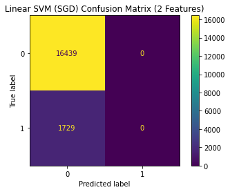

```python
ConfusionMatrixDisplay.from_estimator(
    grid2_reduced.best_estimator_,
    X_test_reduced, y_test
)
plt.title("Linear SVM (SGD) Confusion Matrix (2 Features)")
plt.show()
```

```python
print(classification_report(y_test,
                            grid2_reduced.best_estimator_.predict(X_test_reduced)))
```

```
              precision    recall  f1-score   support

           0       0.90      1.00      0.95     16439
           1       0.00      0.00      0.00      1729

    accuracy                           0.90     18168
   macro avg       0.45      0.50      0.48     18168
weighted avg       0.82      0.90      0.86     18168
```

### 2: Linear SVM (Gradient Descent & Balanced Class Weights)

```python
params_grid3_reduced = grid2_reduced.best_params_.copy()
params_grid3_reduced['class_weight'] = 'balanced'
model3_reduced = SGDClassifier(**params_grid3_reduced)
model3_reduced.fit(X_train_reduced, y_train)
```

```
SGDClassifier(average=True, class_weight='balanced', early_stopping=True,
              eta0=0.001, learning_rate='adaptive', max_iter=5000,
              random_state=42)
```

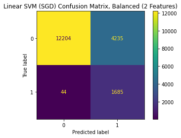

```python
ConfusionMatrixDisplay.from_estimator(model3_reduced,
                                      X_test_reduced, y_test)
plt.title("Linear SVM (SGD) Confusion Matrix, Balanced (2 Features)")
plt.show()
```

```python
print(classification_report(y_test,
                            model3_reduced.predict(X_test_reduced)))
```

```
              precision    recall  f1-score   support

           0       1.00      0.74      0.85     16439
           1       0.28      0.97      0.44      1729

    accuracy                           0.76     18168
   macro avg       0.64      0.86      0.65     18168
weighted avg       0.93      0.76      0.81     18168
```

### 3: Kernel SVM (RBF, Balanced Class Weights, Gradient Descent

```python
params_grid4_reduced = params_grid3_reduced.copy()
```

```python
feature_map_nystroem_reduced = Nystroem(gamma=.9,
                                random_state=1,
                                n_components=300)
```

```python
X_train_reduced_rbf = feature_map_nystroem_reduced.fit_transform(X_train_reduced)
X_test_reduced_rbf = feature_map_nystroem_reduced.transform(X_test_reduced)
```

```python
model4_reduced = SGDClassifier(**params_grid4_reduced)
model4_reduced = model4_reduced.fit(X_train_reduced_rbf, y_train)
```

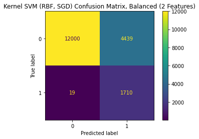

```python
ConfusionMatrixDisplay.from_estimator(model4_reduced, X_test_reduced_rbf, y_test)
plt.title("Kernel SVM (RBF, SGD) Confusion Matrix, Balanced (2 Features)")
plt.show()
```

```python
print(classification_report(y_test,
                            model4_reduced.predict(X_test_reduced_rbf)))
```

```
              precision    recall  f1-score   support

           0       1.00      0.73      0.84     16439
           1       0.28      0.99      0.43      1729

    accuracy                           0.75     18168
   macro avg       0.64      0.86      0.64     18168
weighted avg       0.93      0.75      0.80     18168
```

### 4: One Class SVM

```python
num_positive = X_train_reduced[y_train == 1].shape[0]
outlier_proportion = num_positive / float(X_train_reduced.shape[0])
```

```python
gammas = [0.00001, 0.001, 0.01, 0.05, 0.1, 1, 5, 10, 100]
gamma_kernel_reduced = dict()

for g in gammas:
    feature_map = Nystroem(gamma=g,
                           random_state=1,
                           n_components=300)
    # splitting claases in training data + processing
    X_train, y_train = (
        X_train_reduced[y_train == 0], y_train
    )
    X_test, y_test = (  # note: we include both classes in the test data
        X_test_reduced, y_test
    )
    scaler = StandardScaler()
    X_train_scaled_normal = scaler.fit_transform(X_train)
    X_test_scaled = scaler.transform(X_test)
    # apply the kernel
    X_train_rbf = feature_map.fit_transform(X_train_scaled_normal)
    X_test_rbf = feature_map.transform(X_test_scaled)
    gamma_kernel_reduced[g] = (X_train_rbf, X_test_rbf, y_train, y_test)
```

```python
params4 = {
    'average': True,
    'eta0': 0.001,
    'learning_rate': 'optimal',
    'max_iter': 5000,
    'random_state': 42,
}
```

```python
models_reduced = dict()

for g, X in gamma_kernel_reduced.items():
    X_train_rbf, _, _, _ = X
    svm = SGDOneClassSVM(nu=outlier_proportion,
                         **params4)
    models_reduced[g] = svm.fit(X_train_rbf)
```

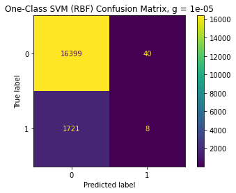

```
              precision    recall  f1-score   support

           0       0.91      1.00      0.95     16439
           1       0.17      0.00      0.01      1729

    accuracy                           0.90     18168
   macro avg       0.54      0.50      0.48     18168
weighted avg       0.83      0.90      0.86     18168
```

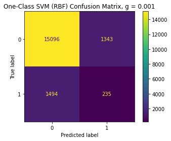

```
              precision    recall  f1-score   support

           0       0.91      0.92      0.91     16439
           1       0.15      0.14      0.14      1729

    accuracy                           0.84     18168
   macro avg       0.53      0.53      0.53     18168
weighted avg       0.84      0.84      0.84     18168
```

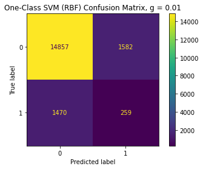

```
              precision    recall  f1-score   support

           0       0.91      0.90      0.91     16439
           1       0.14      0.15      0.15      1729

    accuracy                           0.83     18168
   macro avg       0.53      0.53      0.53     18168
weighted avg       0.84      0.83      0.83     18168
```

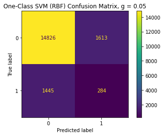

```
              precision    recall  f1-score   support

           0       0.91      0.90      0.91     16439
           1       0.15      0.16      0.16      1729

    accuracy                           0.83     18168
   macro avg       0.53      0.53      0.53     18168
weighted avg       0.84      0.83      0.84     18168
```

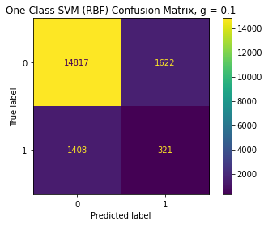

```
              precision    recall  f1-score   support

           0       0.91      0.90      0.91     16439
           1       0.17      0.19      0.17      1729

    accuracy                           0.83     18168
   macro avg       0.54      0.54      0.54     18168
weighted avg       0.84      0.83      0.84     18168
```

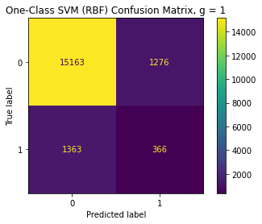

```
              precision    recall  f1-score   support

           0       0.92      0.92      0.92     16439
           1       0.22      0.21      0.22      1729

    accuracy                           0.85     18168
   macro avg       0.57      0.57      0.57     18168
weighted avg       0.85      0.85      0.85     18168
```

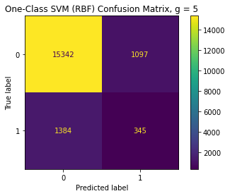

```
              precision    recall  f1-score   support

           0       0.92      0.93      0.93     16439
           1       0.24      0.20      0.22      1729

    accuracy                           0.86     18168
   macro avg       0.58      0.57      0.57     18168
weighted avg       0.85      0.86      0.86     18168
```

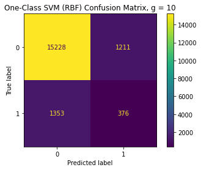

```
              precision    recall  f1-score   support

           0       0.92      0.93      0.92     16439
           1       0.24      0.22      0.23      1729

    accuracy                           0.86     18168
   macro avg       0.58      0.57      0.57     18168
weighted avg       0.85      0.86      0.86     18168
```

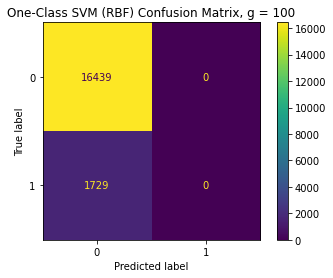

```
              precision    recall  f1-score   support

           0       0.90      1.00      0.95     16439
           1       0.00      0.00      0.00      1729

    accuracy                           0.90     18168
   macro avg       0.45      0.50      0.48     18168
weighted avg       0.82      0.90      0.86     18168
```

```python
for g, X in gamma_kernel_reduced.items():
    _, X_test_rbf, _, y_test = X
    svm = models_reduced[g]
    evaluate_one_class_svm(svm, X_test_rbf, y_test, gamma=g)
```